# R5: di quanto si spostano i trascritti fra il tessuto e la griglia di Visium HD, con quale forma, e quanto è diverso davvero il nucleo dal citoplasma?

geo_spatialtrans, report di step (protocollo v2)

Published

November 3, 2026

## In breve: di quanto si spostano i trascritti fra il tessuto e i quadratini di Visium HD, e quanto è diverso davvero il nucleo dal citoplasma?

**A cosa serviva.** Il simulatore mette i trascritti nelle cellule e poi li deve spostare come fa la tecnologia vera, prima di contarli nei quadratini. Il design prevedeva una sfocatura «a campana» di larghezza da misurare (il commento di Daniele). L’abbiamo misurata dove si vede meglio: ai bordi del tessuto, dove si passa al vetro nudo, in 314 finestre di bordo delle cinque sezioni vere. Poi abbiamo controllato se la stessa sfocatura spiega quello che si vede dentro il tessuto (la differenza fra nucleo e citoplasma) e nei buchi vuoti del tessuto.

**Cosa abbiamo trovato.**

1. **Ai bordi i trascritti si allargano di 3-5 µm, e una parte va molto più lontano.**
   - Larghezza: 3.1 µm nel cervello, 3.4 nel linfonodo, 3.5 nel tumore del colon, 5.2 nell’intestino (oltre i 4 µm che avevamo fissato come limite). Nel cuore 3.2, ma con 5 sole finestre utilizzabili: incerto.
   - In tutte le sezioni c’è una coda: dal 6 % (tumore) al 15 % (cervello) dei trascritti finisce a decine di µm. Una campana sola non basta.
   - Nessuna direzione privilegiata fra righe e colonne della griglia.
   - La larghezza dipende da come si traccia il bordo nell’immagine: con un bordo tracciato in modo diverso cresce di 0.6-2 µm.
2. **Dentro il tessuto la sfocatura è molto più stretta, sotto 1 µm quasi ovunque.**
   - La differenza osservata fra nucleo e citoplasma si spiega con una sfocatura di 0.56-0.84 µm nel tumore, 0.7-2.5 µm nel cervello, circa mezzo µm o meno nello stroma e nel linfonodo. La procedura ritrova i valori giusti su dati costruiti apposta.
   - Con la larghezza dei bordi, la differenza osservata nel linfonodo sarebbe impossibile: nessun rapporto vero la produce.
   - Viceversa, imporre una sfocatura stretta ai bordi peggiora molto l’adattamento: i bordi sono davvero sfumati su 3-5 µm. Sono due scale diverse, e non sappiamo ancora perché (bordo del tessuto sottile o sfrangiato, bordo dell’immagine impreciso, trasporto sul vetro libero).
3. **Prima della diffusione il nucleo è un po’ più diverso dal citoplasma di quanto si osserva.**
   - Nel tumore il nucleo ha 0.7-0.8 volte la densità del citoplasma (osservato circa 0.85); nel cervello circa 1.5 volte (osservato 1.4).
   - Nell’intestino e nel cuore il modello «nucleo e citoplasma con due densità» non riproduce i dati; nello stroma e nel linfonodo la sfocatura è troppo piccola per misurare la correzione.
   - Con la sfocatura dei bordi i valori sarebbero assurdi (nel tumore un nucleo con un sesto della densità del citoplasma, nel cuore 27 volte): solo nel cervello le due strade concordano.
4. **I buchi vuoti vicino al bordo hanno i trascritti previsti dalla sfocatura dei bordi** (entro un quarto in 9 fasce su 10, fino a 8 µm dal bordo del buco). Più all’interno, nel tumore del colon c’è più RNA del previsto (materiale nelle ghiandole), nel cuore meno.
5. **Nell’intestino l’immagine è spostata di 2.4 µm rispetto alla griglia.** Lo stesso spostamento si ritrova dentro il tessuto: allineando le maschere dei nuclei la differenza nucleo/citoplasma cresce, spostandole al contrario si inverte. Nelle altre sezioni lo spostamento è sotto 1 µm o incerto. Conseguenza: nelle impronte dei nuclei dell’intestino che abbiamo usato per i tipi cellulari solo un terzo dei quadratini sta al posto giusto.
6. **Il revisore numerico ha trovato un difetto grave nell’adattamento, e tre controlli scritti prima non sono passati come scritti.**
   - Il difetto: molte finestre restavano bloccate a un limite che non avevamo scritto. È corretto, e tutto è stato rifatto due volte con risultati identici. I numeri sono cambiati (intestino da 4.9 a 5.2 µm; coda del cuore da 0.50 a 0.38), le conclusioni no.
   - I tre controlli: i test su dati costruiti (98 prove su 105), dove falliscono i casi in cui il dato non contiene l’informazione; la lettura della matrice, che contiene geni in più; la controprova dello spostamento della maschera, dove era sbagliata la mia attesa.

**Cosa devi decidere.**

1. **Come sposta i trascritti il simulatore? Consiglio due livelli: una sfocatura piccola per tutti (circa 0.5-1 µm, per tessuto) e, per i trascritti che finiscono fuori dal tessuto (vetro, buchi), l’alone misurato ai bordi (3-5 µm più la coda).**
   - Così i dati simulati hanno sia la differenza nucleo/citoplasma dei dati veri sia l’alone sul vetro e nei buchi, che serve per mettere alla prova i metodi che cercano lo spazio vuoto.
   - Alternativa: una sola campana con la larghezza dei bordi, come nel design. Conseguenza: la differenza fra nucleo e citoplasma sparisce, e i metodi che assegnano i trascritti alle cellule avrebbero dati più difficili dei veri.
   - Alternativa: una sola campana stretta. Conseguenza: niente alone fuori dal tessuto, bordi più netti dei veri.
   - Il come (quali trascritti «escono» e con che regola) si scrive nel design dello Step 2.
2. **Chiudiamo lo step anche se tre controlli non sono passati come scritti? Consiglio di sì.**
   - In tutti e tre il motivo sta nel controllo, non nei dati; il metodo usato è quello registrato, e il revisore ha confermato a identità la lettura dei dati, le tabelle e il modello.
   - Alternativa: rifare i test con geometrie in cui lo spostamento si possa misurare. Conseguenza: un altro giorno di calcolo; i numeri sui dati veri non cambiano.
3. **Che cosa usiamo per il cuore? Consiglio i valori mediani delle altre quattro sezioni, con la riserva scritta nel preset.**
   - Nel cuore ci sono solo 5 bordi utilizzabili, la coda non si separa dalla campana, lo spostamento misurato ai bordi non vale dentro, e il modello dei nuclei non regge.
   - Alternativa: usare le stime del cuore così come sono. Conseguenza: preset con incertezza grande e una coda di peso incerto (0.15-0.62).

**Comunque**: la sfocatura entra nei preset per tessuto, uguale in tutte le direzioni e con la coda; lo spostamento di 2.4 µm dell’intestino va in BACKLOG come riserva sulle impronte dei nuclei di R6; i buchi vuoti si possono riprendere con la sfocatura dei bordi come riferimento per i primi 8 µm; resta da capire perché i bordi siano sfumati più dell’interno.

Appena decidi questi 3 punti, lo step è chiuso.

# Decisioni e verifiche di Luca

- «ok»: ok sulle previsioni e sui quattro intervalli proposti (trascritto dalla chat, 2026-10-31).
- «fai girare tutto che vado a letto»: ok alla seconda esecuzione completa per G-4 (trascritto dalla chat, 2026-10-31).
- «se il server non va usa lesexp-ts» (trascritto dalla chat, 2026-11-01).
- Decisione 1, «Due livelli (Recommended)» (risposta alla domanda «Come deve spostare i trascritti il simulatore nello Step 2?», 2026-11-03): diffusione a due livelli, chiusura con tre controlli falliti come scritti, cuore con la mediana delle altre sezioni (DEC-037).
- Decisione 2, «Sì, chiudi (Recommended)» (2026-11-03): stessa decisione (DEC-037).
- Decisione 3, «Mediana delle altre 4 (Recommended)» (2026-11-03): stessa decisione (DEC-037).

# Dubbi rinviati

| cosa | perché | cosa serve per chiuderlo | step destinatario | voce di BACKLOG |
| --- | --- | --- | --- | --- |
| ai bordi verso il vetro la sfocatura è 3-5 µm, dentro il tessuto sotto 1 µm (tumore, stroma, linfonodo); il meccanismo non è noto (bordo sottile o sfrangiato, imprecisione del bordo H&E, trasporto sul… | decide come lo Step 2 sposta i trascritti dentro e fuori dal tessuto | modello a due livelli nel design dello Step 2; prova su bordi con spessore misurato o con un secondo colorante | S2.0 | BL-197 |
| intestino: immagine spostata di 2.36 µm rispetto alla griglia (confermato dentro il tessuto); solo il 34 % dei bin del nucleo resta allo stesso nucleo con le maschere allineate | le impronte e i tipi cellulari di R6 e i riferimenti di R4 nell’intestino sono letti senza lo spostamento | R6 nell’intestino con le maschere spostate dello scarto della sezione; confronto dei tipi | R6 (ripresa) | BL-198 |
| cuore: 5 finestre di bordo; coda non separabile dalla parte centrale (w 0.15-0.62); scarto dei bordi non valido dentro; il modello a due densità non regge (statistica lontana dal bordo 2.6-4.3) | i preset del cuore non hanno una sfocatura misurata; le impronte dei nuclei (maschera CO) potrebbero essere più grandi dei nuclei | più bordi (altre sezioni di cuore) e un controllo delle impronte dei nuclei sull’immagine | R3b / da assegnare | BL-199 |
| linfonodo: molte finestre di bordo sono tessuto adiposo (il «vetro» H&E vicino al tessuto resta a 0.2-0.25 del livello del tessuto per oltre 100 µm); σ a due gruppi (17 tessere al limite di 0.2 µm) | la larghezza del linfonodo mescola bordi veri e adipociti | selezione delle finestre con una maschera degli adipociti | da assegnare | BL-200 |
| lumi del tumore del colon con più RNA del previsto oltre 8 µm dal bordo (1.46-1.52) e lumi del cuore con meno (0.65-0.71); cervello con 2 soli lumi | per lo spazio acellulare (BL-077) la soglia non può venire dalla sola sfocatura dei bordi oltre 8 µm | lumi annotati (muco, residui) e più lumi nel cervello | S2.0 (spazio acellulare) | BL-201 |
| G-1: asserzioni di identificabilità (scarto parallelo al bordo, σ = 5 µm su geometrie piccole) e semi non riproducibili nella prima versione | il cancello come scritto non distingue i difetti di codice dai limiti del dato | batteria con geometrie in cui ogni parametro è identificabile, tolleranze dalla teoria (informazione di Fisher) | protocollo (skill) | BL-202 |

# Cancelli

Cancelli

| id | controllo | esito |
| --- | --- | --- |
| G-1 | batteria di test su dati sintetici e mutanti (`tools/R5_test.py`) | R5_test: 98/105 PASS (19836 s) |
| G-2 | md5 di ogni file letto, prima e dopo (`tools/R5_md5.sh`) | G-2: PASS (159 files identical before and after) |
| G-3 | lettura dei dati (`tools/R5_check.py`) | G-3: come scritto FALLITO ((a) con tutte le feature della grezza); con il pannello della filtrata (DV-1) PASS (a, b, c, d) |
| G-4 | riproducibilità: due esecuzioni complete con il post hoc (`tools/R5_chain2.sh`, `tools/R5_repro2.sh`) | G-4: 24/24 files identical (/mnt/micron/geo_spatialtrans/R5/run3 vs /mnt/micron/geo_spatialtrans/R5/run4) |
| G-5 | revisione avversariale (codice e numeri) | vedi «Revisione avversariale» |

# Nucleo di diffusione dai bordi del tessuto (P-1…P-4)

Previsioni sui bordi: mediana delle tessere, bootstrap per blocchi sulle tessere (B = 2000)

| sezione | id | quantità | stima | lo | hi | intervallo | esito | tessere |
| --- | --- | --- | --- | --- | --- | --- | --- | --- |
| intestino di topo | P-1 | sigma K2 (um) | 5.160 | 4.875 | 5.529 | [1, 4] | smentita | 130 |
| intestino di topo | P-2 | tail mass w K2 | 0.099 | 0.088 | 0.110 | [0, 0.01] trascurabile | confermata | 130 |
| intestino di topo | P-3 | sigma_row/sigma_col K3 | 0.983 | 0.899 | 1.043 | [0.8, 1.25] | confermata | 130 |
| intestino di topo | P-4 | \|delta\| (um), median vector | 2.360 | 2.041 | 2.635 | [0, 1] | smentita | 130 |
| tumore del colon (e stroma) | P-1 | sigma K2 (um) | 3.461 | 3.352 | 3.975 | [1, 4] | confermata | 59 |
| tumore del colon (e stroma) | P-2 | tail mass w K2 | 0.058 | 0.049 | 0.069 | [0, 0.01] trascurabile | confermata | 59 |
| tumore del colon (e stroma) | P-3 | sigma_row/sigma_col K3 | 0.990 | 0.931 | 1.057 | [0.8, 1.25] | confermata | 59 |
| tumore del colon (e stroma) | P-4 | \|delta\| (um), median vector | 0.173 | 0.082 | 0.654 | [0, 1] | confermata | 59 |
| linfonodo | P-1 | sigma K2 (um) | 3.372 | 2.463 | 3.769 | [1, 4] | confermata | 73 |
| linfonodo | P-2 | tail mass w K2 | 0.121 | 0.084 | 0.209 | [0, 0.01] trascurabile | confermata | 73 |
| linfonodo | P-3 | sigma_row/sigma_col K3 | 1.000 | 0.894 | 1.000 | [0.8, 1.25] | confermata | 73 |
| linfonodo | P-4 | \|delta\| (um), median vector | 0.574 | 0.336 | 1.389 | [0, 1] | indeterminata | 73 |
| cervello di topo | P-1 | sigma K2 (um) | 3.084 | 2.407 | 3.622 | [1, 4] | confermata | 47 |
| cervello di topo | P-2 | tail mass w K2 | 0.151 | 0.117 | 0.213 | [0, 0.01] trascurabile | confermata | 47 |
| cervello di topo | P-3 | sigma_row/sigma_col K3 | 0.988 | 0.862 | 1.156 | [0.8, 1.25] | confermata | 47 |
| cervello di topo | P-4 | \|delta\| (um), median vector | 0.491 | 0.211 | 2.021 | [0, 1] | senza attesa (indeterminata) | 47 |
| cuore | P-1 | sigma K2 (um) | 3.236 | 2.513 | 5.074 | [1, 4] | indeterminata | 5 |
| cuore | P-2 | tail mass w K2 | 0.382 | 0.145 | 0.618 | [0, 0.01] trascurabile | confermata | 5 |
| cuore | P-3 | sigma_row/sigma_col K3 | 0.749 | 0.213 | 1.893 | [0.8, 1.25] | indeterminata | 5 |
| cuore | P-4 | \|delta\| (um), median vector | 2.256 | 0.703 | 6.146 | [0, 1] | indeterminata | 5 |
| tutte | R-2 | max/min sigma | 1.673 | 1.544 | 2.235 | 1.25 | sigma per tessuto | NA |

D-2, D-3, D-4: fondo, coda, spostamento medio, frazione oltre 2…32 µm, variabilità dello scarto fra tessere

| key | sigma | w | ell | b_tiles_median | b_far | b_far_rule | a_median | mean_displacement_um | frac_beyond_2um | frac_beyond_4um | frac_beyond_8um | frac_beyond_16um | frac_beyond_32um | delta_spread_iqr_dr | delta_spread_iqr_dc |
| --- | --- | --- | --- | --- | --- | --- | --- | --- | --- | --- | --- | --- | --- | --- | --- |
| A1 | 5.160 | 0.099 | 26.809 | 0.254 | 0.161 | distance >= 300 um | 0.952 | 11.131 | 0.935 | 0.765 | 0.366 | 0.094 | 0.066 | 1.521 | 1.774 |
| A23 | 3.461 | 0.058 | 15.029 | 0.528 | 0.197 | distance >= 300 um | 1.002 | 5.831 | 0.855 | 0.539 | 0.117 | 0.041 | 0.022 | 1.612 | 1.751 |
| A4 | 3.372 | 0.121 | 38.086 | 0.031 | 0.042 | distance >= 300 um | 0.875 | 12.911 | 0.858 | 0.555 | 0.171 | 0.113 | 0.096 | 2.325 | 1.744 |
| A5 | 3.084 | 0.151 | 21.821 | 0.702 | 0.309 | distance >= 300 um | 1.153 | 9.856 | 0.838 | 0.515 | 0.172 | 0.125 | 0.086 | 3.641 | 4.811 |
| A6 | 3.236 | 0.382 | 11.658 | 0.140 | 0.117 | farthest 10000 bins (>= 192 um) | 1.005 | 11.422 | 0.888 | 0.652 | 0.354 | 0.230 | 0.092 | 4.445 | 2.246 |

Sensibilità

| key | variant | n_tiles | sigma | w | ell | dr | dc | ratio_K3 | abs_delta |
| --- | --- | --- | --- | --- | --- | --- | --- | --- | --- |
| A1 | primary (as pre-registered: b free, rho from all tissue bins) | 130 | 5.160 | 0.099 | 26.809 | 0.232 | -2.348 | NA | NA |
| A1 | S-0 b fixed from far glass | 130 | 5.519 | 0.084 | 39.760 | 0.211 | -2.305 | NA | NA |
| A1 | S-1 alternative H&E mask | 130 | 6.069 | 0.117 | 23.708 | 0.040 | -2.095 | NA | NA |
| A1 | S-2 parity from glass | 130 | 5.164 | 0.099 | 26.913 | 0.233 | -2.348 | NA | NA |
| A1 | S-3 glass-only likelihood | 130 | 5.435 | 0.137 | 24.114 | 0.442 | -2.939 | NA | NA |
| A1 | S-4 central 200 um | 130 | 4.938 | 0.104 | 26.031 | -0.010 | -2.408 | NA | NA |
| A1 | S-W w <= 0.5 (bound of the first version) | 130 | 5.160 | 0.099 | 26.809 | 0.232 | -2.348 | NA | NA |
| A1 | K1 Gaussian only | 130 | 6.388 | 0.000 | 30.000 | 0.197 | -2.285 | NA | NA |
| A1 | Fisher-weighted delta (K2) | 130 | NA | NA | NA | -0.058 | -2.174 | NA | NA |
| A1 | K2 converged and not at bounds | 76 | 5.332 | 0.107 | 24.791 | 0.232 | -2.479 | NA | NA |
| A1 | tiles without tissue outside the array | 130 | 5.160 | 0.099 | 26.809 | 0.232 | -2.348 | NA | NA |
| A1 | P-3 ratio, K3 moved from start and not at bounds | 108 | NA | NA | NA | NA | NA | 0.962 | NA |
| A1 | P-4 alternative: median of per-tile \|delta\| | 130 | NA | NA | NA | NA | NA | NA | 2.618 |
| A1 | fits at bounds or not converged (counts) | 130 | NA | NA | NA | NA | NA | NA | NA |
| A23 | primary (as pre-registered: b free, rho from all tissue bins) | 59 | 3.461 | 0.058 | 15.029 | 0.065 | -0.161 | NA | NA |
| A23 | S-0 b fixed from far glass | 59 | 3.672 | 0.053 | 47.840 | 0.096 | -0.188 | NA | NA |
| A23 | S-1 alternative H&E mask | 59 | 4.491 | 0.049 | 20.185 | 0.349 | 0.012 | NA | NA |
| A23 | S-2 parity from glass | 59 | 3.459 | 0.058 | 14.988 | 0.066 | -0.162 | NA | NA |
| A23 | S-3 glass-only likelihood | 59 | 3.556 | 0.083 | 12.767 | 0.059 | -0.412 | NA | NA |
| A23 | S-4 central 200 um | 58 | 3.350 | 0.047 | 15.567 | 0.393 | -0.225 | NA | NA |
| A23 | S-W w <= 0.5 (bound of the first version) | 59 | 3.461 | 0.058 | 15.029 | 0.065 | -0.161 | NA | NA |
| A23 | K1 Gaussian only | 59 | 3.904 | 0.000 | 30.000 | 0.074 | -0.133 | NA | NA |
| A23 | Fisher-weighted delta (K2) | 59 | NA | NA | NA | 0.217 | -0.127 | NA | NA |
| A23 | K2 converged and not at bounds | 29 | 3.512 | 0.051 | 15.177 | 0.115 | -0.161 | NA | NA |
| A23 | tiles without tissue outside the array | 56 | 3.463 | 0.055 | 15.103 | 0.120 | 0.078 | NA | NA |
| A23 | P-3 ratio, K3 moved from start and not at bounds | 44 | NA | NA | NA | NA | NA | 0.954 | NA |
| A23 | P-4 alternative: median of per-tile \|delta\| | 59 | NA | NA | NA | NA | NA | NA | 1.385 |
| A23 | fits at bounds or not converged (counts) | 59 | NA | NA | NA | NA | NA | NA | NA |
| A4 | primary (as pre-registered: b free, rho from all tissue bins) | 73 | 3.372 | 0.121 | 38.086 | 0.552 | -0.157 | NA | NA |
| A4 | S-0 b fixed from far glass | 73 | 2.793 | 0.094 | 64.187 | 0.577 | -0.208 | NA | NA |
| A4 | S-1 alternative H&E mask | 73 | 4.016 | 0.105 | 36.279 | 0.443 | -0.169 | NA | NA |
| A4 | S-2 parity from glass | 73 | 3.320 | 0.121 | 34.263 | 0.555 | -0.166 | NA | NA |
| A4 | S-3 glass-only likelihood | 73 | 3.304 | 0.200 | 36.510 | 0.891 | 0.180 | NA | NA |
| A4 | S-4 central 200 um | 73 | 2.834 | 0.124 | 34.600 | 0.595 | -0.177 | NA | NA |
| A4 | S-W w <= 0.5 (bound of the first version) | 73 | 3.584 | 0.121 | 38.086 | 0.567 | -0.167 | NA | NA |
| A4 | K1 Gaussian only | 73 | 4.128 | 0.000 | 30.000 | 0.503 | -0.208 | NA | NA |
| A4 | Fisher-weighted delta (K2) | 73 | NA | NA | NA | 0.617 | -0.205 | NA | NA |
| A4 | K2 converged and not at bounds | 23 | 3.952 | 0.127 | 39.169 | 1.039 | -0.303 | NA | NA |
| A4 | tiles without tissue outside the array | 68 | 3.348 | 0.108 | 38.628 | 0.419 | -0.162 | NA | NA |
| A4 | P-3 ratio, K3 moved from start and not at bounds | 30 | NA | NA | NA | NA | NA | 1.036 | NA |
| A4 | P-4 alternative: median of per-tile \|delta\| | 73 | NA | NA | NA | NA | NA | NA | 1.998 |
| A4 | fits at bounds or not converged (counts) | 73 | NA | NA | NA | NA | NA | NA | NA |
| A5 | primary (as pre-registered: b free, rho from all tissue bins) | 47 | 3.084 | 0.151 | 21.821 | -0.112 | -0.478 | NA | NA |
| A5 | S-0 b fixed from far glass | 47 | 3.845 | 0.099 | 70.666 | -0.062 | -0.474 | NA | NA |
| A5 | S-1 alternative H&E mask | 47 | 3.982 | 0.129 | 23.246 | -0.515 | -0.298 | NA | NA |
| A5 | S-2 parity from glass | 47 | 3.079 | 0.151 | 21.823 | -0.111 | -0.478 | NA | NA |
| A5 | S-3 glass-only likelihood | 47 | 4.485 | 0.167 | 27.649 | 0.551 | -0.049 | NA | NA |
| A5 | S-4 central 200 um | 47 | 2.662 | 0.255 | 13.683 | -0.625 | -0.300 | NA | NA |
| A5 | S-W w <= 0.5 (bound of the first version) | 47 | 3.094 | 0.151 | 21.821 | -0.095 | -0.478 | NA | NA |
| A5 | K1 Gaussian only | 47 | 5.091 | 0.000 | 30.000 | 0.014 | -0.560 | NA | NA |
| A5 | Fisher-weighted delta (K2) | 47 | NA | NA | NA | -0.279 | -1.095 | NA | NA |
| A5 | K2 converged and not at bounds | 15 | 3.344 | 0.212 | 14.101 | -0.112 | 0.872 | NA | NA |
| A5 | tiles without tissue outside the array | 47 | 3.084 | 0.151 | 21.821 | -0.112 | -0.478 | NA | NA |
| A5 | P-3 ratio, K3 moved from start and not at bounds | 36 | NA | NA | NA | NA | NA | 1.000 | NA |
| A5 | P-4 alternative: median of per-tile \|delta\| | 47 | NA | NA | NA | NA | NA | NA | 2.567 |
| A5 | fits at bounds or not converged (counts) | 47 | NA | NA | NA | NA | NA | NA | NA |
| A6 | primary (as pre-registered: b free, rho from all tissue bins) | 5 | 3.236 | 0.382 | 11.658 | -2.029 | 0.985 | NA | NA |
| A6 | S-0 b fixed from far glass | 5 | 3.849 | 0.337 | 9.571 | -2.039 | 0.982 | NA | NA |
| A6 | S-1 alternative H&E mask | 5 | 5.293 | 0.161 | 21.753 | -2.447 | 1.563 | NA | NA |
| A6 | S-2 parity from glass | 5 | 3.236 | 0.380 | 11.655 | -2.029 | 0.985 | NA | NA |
| A6 | S-3 glass-only likelihood | 5 | 3.249 | 0.442 | 7.487 | -1.063 | 0.753 | NA | NA |
| A6 | S-4 central 200 um | 5 | 2.947 | 0.362 | 8.818 | 1.125 | 1.716 | NA | NA |
| A6 | S-W w <= 0.5 (bound of the first version) | 5 | 3.306 | 0.382 | 11.658 | -2.029 | 0.985 | NA | NA |
| A6 | K1 Gaussian only | 5 | 7.045 | 0.000 | 30.000 | -1.970 | 1.886 | NA | NA |
| A6 | Fisher-weighted delta (K2) | 5 | NA | NA | NA | -0.486 | 1.274 | NA | NA |
| A6 | K2 converged and not at bounds | 3 | 3.306 | 0.382 | 6.679 | 0.666 | 0.985 | NA | NA |
| A6 | tiles without tissue outside the array | 4 | 3.115 | 0.378 | 13.220 | -2.904 | 1.797 | NA | NA |
| A6 | P-3 ratio, K3 moved from start and not at bounds | 4 | NA | NA | NA | NA | NA | 1.028 | NA |
| A6 | P-4 alternative: median of per-tile \|delta\| | 5 | NA | NA | NA | NA | NA | NA | 3.312 |
| A6 | fits at bounds or not converged (counts) | 5 | NA | NA | NA | NA | NA | NA | NA |

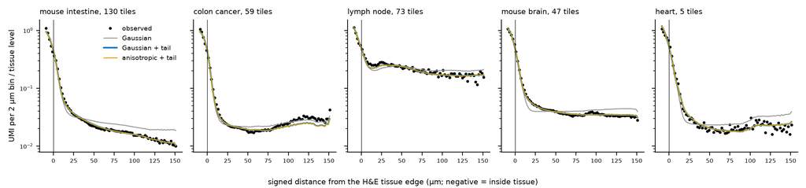

*Cosa guardare*: i conteggi (punti) scendono dal tessuto al vetro in 3-5 µm e poi restano sopra il fondo per decine di µm (coda); la sola gaussiana (K1) non segue la coda.

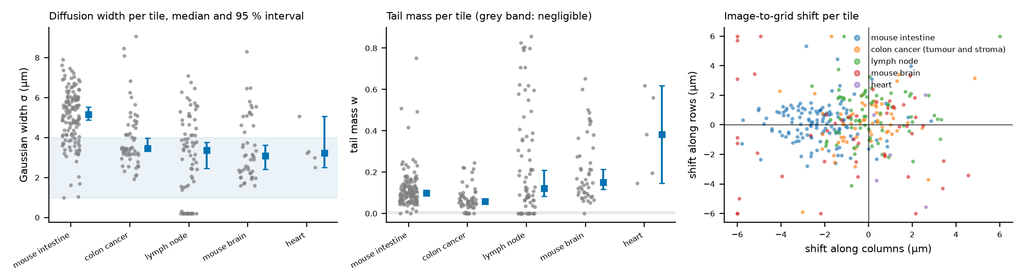

# Lumi (CP-2) e spostamento della maschera (CP-3)

CP-2: UMI osservati/previsti nei lumi interni per fascia di distanza dal bordo

| key | band_um | n_lumens | n_tiles | n_bins | obs_per_bin | pred_per_bin | ratio | lo | hi | verdict |
| --- | --- | --- | --- | --- | --- | --- | --- | --- | --- | --- |
| A1 | 2-4 | 138 | 104 | 37213 | 8.145 | 7.683 | 1.060 | 1.018 | 1.098 | confermata |
| A1 | 4-8 | 138 | 104 | 62934 | 5.275 | 4.746 | 1.111 | 1.053 | 1.165 | confermata |
| A1 | 8-16 | 138 | 104 | 62554 | 2.770 | 2.187 | 1.266 | 1.172 | 1.354 | indeterminata |
| A1 | 16-32 | 138 | 104 | 29015 | 1.790 | 1.383 | 1.294 | 1.191 | 1.382 | indeterminata |
| A23 | 2-4 | 50 | 43 | 13193 | 4.880 | 6.181 | 0.790 | 0.718 | 0.851 | indeterminata |
| A23 | 4-8 | 50 | 43 | 23690 | 2.885 | 2.596 | 1.111 | 1.008 | 1.220 | confermata |
| A23 | 8-16 | 50 | 43 | 30233 | 1.904 | 1.256 | 1.516 | 1.336 | 1.739 | smentita |
| A23 | 16-32 | 50 | 43 | 17920 | 1.486 | 1.019 | 1.458 | 1.217 | 1.766 | indeterminata |
| A4 | 2-4 | 446 | 130 | 62071 | 0.120 | 0.112 | 1.075 | 1.018 | 1.128 | confermata |
| A4 | 4-8 | 446 | 130 | 108379 | 0.090 | 0.075 | 1.195 | 1.122 | 1.266 | indeterminata |
| A4 | 8-16 | 446 | 130 | 146829 | 0.075 | 0.062 | 1.220 | 1.140 | 1.307 | indeterminata |
| A4 | 16-32 | 446 | 130 | 86323 | 0.066 | 0.059 | 1.127 | 1.017 | 1.239 | confermata |
| A5 | 2-4 | 2 | 2 | 619 | 4.522 | 5.292 | 0.854 | 0.697 | 0.910 | indeterminata |
| A5 | 4-8 | 2 | 2 | 1117 | 2.391 | 2.955 | 0.809 | 0.590 | 0.882 | indeterminata |
| A5 | 8-16 | 2 | 2 | 1518 | 1.419 | 2.273 | 0.624 | 0.473 | 0.677 | smentita |
| A5 | 16-32 | 2 | 2 | 730 | 1.074 | 2.096 | 0.512 | 0.400 | 0.585 | smentita |
| A6 | 2-4 | 53 | 48 | 13248 | 1.418 | 1.314 | 1.079 | 0.970 | 1.201 | confermata |
| A6 | 4-8 | 53 | 48 | 22615 | 0.822 | 0.947 | 0.869 | 0.762 | 0.976 | indeterminata |
| A6 | 8-16 | 53 | 48 | 22940 | 0.482 | 0.676 | 0.713 | 0.581 | 0.854 | indeterminata |
| A6 | 16-32 | 53 | 48 | 10156 | 0.263 | 0.407 | 0.645 | 0.438 | 0.928 | indeterminata |

CP-3: variazione dello scarto stimato con la maschera spostata di (+2, −2) µm

| key | d_dr_median | d_dr_lo | d_dr_hi | d_dc_median | d_dc_lo | d_dc_hi | sigma_K2 | sigma_CP3 | w_K2 | w_CP3 | pass |
| --- | --- | --- | --- | --- | --- | --- | --- | --- | --- | --- | --- |
| A1 | -1.345 | -1.410 | -1.315 | 1.398 | 1.368 | 1.415 | 5.160 | 5.101 | 0.099 | 0.100 | False |
| A23 | -1.539 | -1.615 | -1.490 | 1.507 | 1.453 | 1.586 | 3.461 | 3.464 | 0.058 | 0.061 | False |
| A4 | -1.204 | -1.411 | -0.934 | 1.257 | 1.198 | 1.405 | 3.372 | 3.209 | 0.121 | 0.121 | False |
| A5 | -1.548 | -1.654 | -1.476 | 1.490 | 1.209 | 1.657 | 3.084 | 2.991 | 0.151 | 0.165 | False |
| A6 | -1.580 | -1.755 | -0.445 | 1.594 | 1.007 | 3.370 | 3.236 | 3.438 | 0.382 | 0.386 | False |

PH-1: la stessa prova su tessere sintetiche

| sigma_true | dc_true | rep | orig_sigma | orig_w | orig_dr | orig_dc | shift_sigma | shift_w | shift_dr | shift_dc | resp_dr | resp_dc |
| --- | --- | --- | --- | --- | --- | --- | --- | --- | --- | --- | --- | --- |
| 2 | 0.0 | 0 | 1.924 | 0.088 | 0.045 | 0.181 | 2.134 | 0.087 | -1.504 | 1.888 | -1.549 | 1.707 |
| 2 | 0.0 | 1 | 1.811 | 0.085 | -0.351 | 0.014 | 1.834 | 0.090 | -2.222 | 1.899 | -1.870 | 1.885 |
| 2 | 0.0 | 2 | 1.987 | 0.100 | 0.250 | 0.295 | 2.034 | 0.101 | -1.541 | 2.123 | -1.790 | 1.828 |
| 2 | 0.0 | 3 | 1.725 | 0.077 | -0.718 | 0.020 | 1.760 | 0.076 | -2.590 | 1.879 | -1.872 | 1.859 |
| 2 | 0.0 | 4 | 2.040 | 0.085 | 0.184 | 0.853 | 2.090 | 0.086 | -1.654 | 2.742 | -1.838 | 1.889 |
| 2 | 0.0 | 5 | 1.873 | 0.083 | -0.359 | 0.465 | 2.004 | 0.080 | -2.047 | 2.172 | -1.688 | 1.707 |
| 2 | 0.0 | 6 | 2.108 | 0.085 | 0.549 | 0.552 | 2.312 | 0.085 | -0.944 | 2.077 | -1.492 | 1.525 |
| 2 | 0.0 | 7 | 1.975 | 0.075 | 0.123 | 0.049 | 2.097 | 0.075 | -1.571 | 1.742 | -1.693 | 1.692 |
| 2 | 0.0 | 8 | 1.903 | 0.097 | 0.091 | 0.021 | 1.983 | 0.096 | -1.730 | 1.861 | -1.821 | 1.840 |
| 2 | 0.0 | 9 | 1.908 | 0.094 | -0.058 | 0.372 | 1.988 | 0.094 | -1.876 | 2.011 | -1.818 | 1.639 |
| 2 | -2.5 | 0 | 1.844 | 0.109 | 0.183 | -1.735 | 1.880 | 0.106 | -1.718 | 0.088 | -1.901 | 1.824 |
| 2 | -2.5 | 1 | 1.835 | 0.082 | -0.222 | -2.206 | 1.855 | 0.084 | -2.072 | -0.552 | -1.850 | 1.654 |
| 2 | -2.5 | 2 | 1.741 | 0.092 | -0.291 | -2.428 | 1.719 | 0.098 | -2.215 | -0.585 | -1.925 | 1.843 |
| 2 | -2.5 | 3 | 1.825 | 0.091 | -0.236 | -2.425 | 1.866 | 0.093 | -2.075 | -0.679 | -1.838 | 1.747 |
| 2 | -2.5 | 4 | 1.804 | 0.087 | 0.047 | -2.666 | 1.840 | 0.092 | -1.816 | -0.956 | -1.863 | 1.710 |
| 2 | -2.5 | 5 | 2.157 | 0.102 | 0.740 | -2.465 | 2.282 | 0.101 | -0.909 | -0.993 | -1.649 | 1.472 |
| 2 | -2.5 | 6 | 1.896 | 0.087 | -0.301 | -2.011 | 1.892 | 0.093 | -2.226 | -0.280 | -1.925 | 1.731 |
| 2 | -2.5 | 7 | 2.181 | 0.080 | 0.776 | -2.418 | 2.247 | 0.085 | -1.022 | -0.809 | -1.798 | 1.609 |
| 2 | -2.5 | 8 | 1.937 | 0.089 | 0.094 | -1.933 | 1.983 | 0.088 | -1.748 | -0.150 | -1.842 | 1.783 |
| 2 | -2.5 | 9 | 2.064 | 0.079 | 0.644 | -1.769 | 2.077 | 0.080 | -1.299 | 0.176 | -1.943 | 1.945 |
| 5 | 0.0 | 0 | 5.050 | 0.074 | 0.376 | -1.640 | 5.135 | 0.074 | -1.219 | -0.347 | -1.596 | 1.293 |
| 5 | 0.0 | 1 | 5.419 | 0.063 | 1.004 | -0.243 | 5.568 | 0.065 | -0.552 | 1.273 | -1.556 | 1.516 |
| 5 | 0.0 | 2 | 4.491 | 0.087 | -0.545 | 1.077 | 4.626 | 0.088 | -2.289 | 2.801 | -1.744 | 1.723 |
| 5 | 0.0 | 3 | 4.921 | 0.081 | -0.301 | 0.009 | 5.096 | 0.079 | -1.855 | 1.535 | -1.554 | 1.526 |
| 5 | 0.0 | 4 | 4.942 | 0.079 | 0.930 | -0.151 | 5.083 | 0.083 | -0.464 | 1.424 | -1.394 | 1.575 |
| 5 | 0.0 | 5 | 4.739 | 0.089 | -0.488 | -1.062 | 4.887 | 0.090 | -2.040 | 0.356 | -1.551 | 1.418 |
| 5 | 0.0 | 6 | 4.562 | 0.083 | 0.653 | -0.120 | 4.652 | 0.083 | -0.977 | 1.360 | -1.630 | 1.479 |
| 5 | 0.0 | 7 | 4.773 | 0.092 | 0.194 | 0.264 | 4.841 | 0.095 | -1.643 | 1.862 | -1.838 | 1.598 |
| 5 | 0.0 | 8 | 4.941 | 0.070 | -0.187 | -0.094 | 5.006 | 0.071 | -1.858 | 1.612 | -1.671 | 1.706 |
| 5 | 0.0 | 9 | 4.619 | 0.100 | -0.359 | 0.640 | 4.787 | 0.102 | -1.897 | 2.110 | -1.538 | 1.469 |
| 5 | -2.5 | 0 | 4.316 | 0.093 | -0.093 | -2.622 | 4.485 | 0.091 | -1.429 | -1.263 | -1.335 | 1.359 |
| 5 | -2.5 | 1 | 4.619 | 0.075 | -0.412 | -1.979 | 4.667 | 0.082 | -2.204 | -0.558 | -1.792 | 1.420 |
| 5 | -2.5 | 2 | 5.177 | 0.064 | -0.254 | -2.772 | 5.200 | 0.067 | -2.091 | -1.078 | -1.836 | 1.694 |
| 5 | -2.5 | 3 | 4.792 | 0.082 | -1.312 | -2.470 | 4.816 | 0.085 | -3.059 | -0.908 | -1.748 | 1.562 |
| 5 | -2.5 | 4 | 5.336 | 0.067 | 0.115 | -1.971 | 5.350 | 0.069 | -1.712 | -0.467 | -1.827 | 1.504 |
| 5 | -2.5 | 5 | 5.258 | 0.077 | 0.799 | -2.640 | 5.323 | 0.079 | -0.754 | -1.248 | -1.553 | 1.392 |
| 5 | -2.5 | 6 | 4.481 | 0.080 | -0.314 | -3.069 | 4.552 | 0.083 | -1.910 | -1.579 | -1.596 | 1.490 |
| 5 | -2.5 | 7 | 4.648 | 0.089 | 0.084 | -2.742 | 4.681 | 0.093 | -1.519 | -1.195 | -1.602 | 1.547 |
| 5 | -2.5 | 8 | 4.440 | 0.078 | -1.469 | -1.932 | 4.469 | 0.081 | -3.224 | -0.330 | -1.755 | 1.602 |
| 5 | -2.5 | 9 | 4.817 | 0.078 | -0.277 | -1.981 | 4.886 | 0.077 | -1.959 | -0.389 | -1.683 | 1.591 |

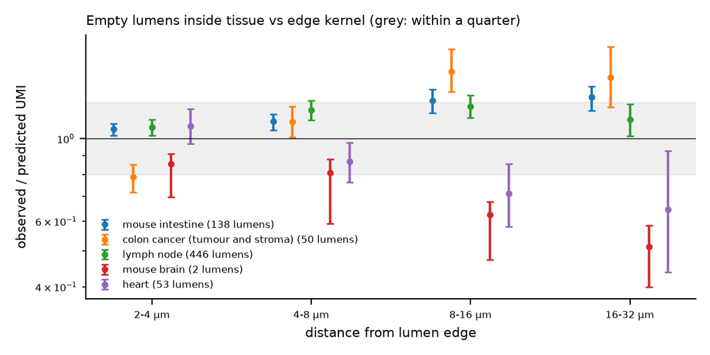

# Rapporto nucleo/citoplasma prima della diffusione (P-5, CP-1)

P-5 e CP-1 con il nucleo dei bordi: come scritti e con le sole ROI riuscite (sensibilità dichiarata)

| tessuto | id | variante | stima | lo | hi | esito | ROI fallite |
| --- | --- | --- | --- | --- | --- | --- | --- |
| intestino di topo | P-5 | as written (all ROIs) | — | — | — | non calcolabile come scritto | 4 |
| intestino di topo | CP-1 (descrittiva) | as written (all ROIs) | — | — | — | non calcolabile come scritto | 4 |
| intestino di topo | P-5 | sensitivity: successful ROIs only (nanmean) | 0.111 | 0.052 | 0.184 | smentita | 4 |
| intestino di topo | CP-1 (descrittiva) | sensitivity: successful ROIs only (nanmean) | 0.957 | 0.915 | 0.964 | confermata | 4 |
| tumore del colon | P-5 | as written (all ROIs) | — | — | — | non calcolabile come scritto | 1 |
| tumore del colon | CP-1 | as written (all ROIs) | — | — | — | non calcolabile come scritto | 1 |
| tumore del colon | P-5 | sensitivity: successful ROIs only (nanmean) | 0.153 | 0.077 | 0.232 | confermata | 1 |
| tumore del colon | CP-1 | sensitivity: successful ROIs only (nanmean) | 0.871 | 0.848 | 0.944 | indeterminata | 1 |
| stroma del tumore | P-5 | as written (all ROIs) | — | — | — | non calcolabile come scritto | 1 |
| stroma del tumore | CP-1 (descrittiva) | as written (all ROIs) | — | — | — | non calcolabile come scritto | 1 |
| stroma del tumore | P-5 | sensitivity: successful ROIs only (nanmean) | 0.360 | 0.132 | 0.482 | confermata | 1 |
| stroma del tumore | CP-1 (descrittiva) | sensitivity: successful ROIs only (nanmean) | 0.903 | 0.855 | 0.990 | indeterminata | 1 |
| linfonodo | P-5 | as written (all ROIs) | — | — | — | non calcolabile come scritto | 5 |
| linfonodo | CP-1 | as written (all ROIs) | — | — | — | non calcolabile come scritto | 5 |
| linfonodo | P-5 | sensitivity: successful ROIs only (nanmean) | — | — | — | non calcolabile | 5 |
| linfonodo | CP-1 | sensitivity: successful ROIs only (nanmean) | — | — | — | non calcolabile | 5 |
| cervello di topo | P-5 | as written (all ROIs) | 1.775 | 1.622 | 1.949 | confermata | 0 |
| cervello di topo | CP-1 | as written (all ROIs) | 1.026 | 1.007 | 1.048 | confermata | 0 |
| cervello di topo | P-5 | sensitivity: successful ROIs only (nanmean) | 1.775 | 1.622 | 1.949 | confermata | 0 |
| cervello di topo | CP-1 | sensitivity: successful ROIs only (nanmean) | 1.026 | 1.007 | 1.048 | confermata | 0 |
| cuore | P-5 | as written (all ROIs) | 27.365 | — | — | non calcolabile come scritto | 0 |
| cuore | CP-1 | as written (all ROIs) | 0.766 | — | — | non calcolabile come scritto | 0 |
| cuore | P-5 | sensitivity: successful ROIs only (nanmean) | 27.365 | 9.988 | 36.591 | confermata | 0 |
| cuore | CP-1 | sensitivity: successful ROIs only (nanmean) | 0.766 | 0.547 | 0.810 | smentita | 0 |

PH-3: intervallo della statistica raggiungibile con il nucleo dei bordi per r da 0.05 a 50

| tag | archetype | obs_star | stat_r0.05 | stat_r1 | stat_r50 | reachable |
| --- | --- | --- | --- | --- | --- | --- |
| A1_r1 | A1 | 0.973 | 0.995 | 1.032 | 1.170 | False |
| A1_r2 | A1 | 0.968 | 0.990 | 1.026 | 1.160 | False |
| A1_r3 | A1 | 1.001 | 0.990 | 1.026 | 1.153 | True |
| A1_r4 | A1 | 0.990 | 0.987 | 1.023 | 1.146 | True |
| A1_r5 | A1 | 0.995 | 0.981 | 1.017 | 1.143 | True |
| A2_r1 | A2 | 0.821 | 0.821 | 1.018 | 1.494 | True |
| A2_r2 | A2 | 0.863 | 0.822 | 1.009 | 1.520 | True |
| A2_r3 | A2 | 0.878 | 0.809 | 1.014 | 1.539 | True |
| A2_r4 | A2 | 0.823 | 0.804 | 1.011 | 1.457 | True |
| A2_r5 | A2 | 0.850 | 0.804 | 1.013 | 1.525 | True |
| A3_r1 | A3 | 0.867 | 0.796 | 1.021 | 1.809 | True |
| A3_r2 | A3 | 0.953 | 0.831 | 1.023 | 1.939 | True |
| A3_r3 | A3 | 0.893 | 0.792 | 1.025 | 1.814 | True |
| A3_r4 | A3 | 0.918 | 0.852 | 1.016 | 1.577 | True |
| A3_r5 | A3 | 0.828 | 0.817 | 1.010 | 1.479 | True |
| A4_f1 | A4 | 0.761 | 0.945 | 0.999 | 1.085 | False |
| A4_f2 | A4 | 0.771 | 0.950 | 0.999 | 1.078 | False |
| A4_p1 | A4 | 0.799 | 0.964 | 0.996 | 1.041 | False |
| A4_p2 | A4 | 0.806 | 0.957 | 0.996 | 1.052 | False |
| A4_p3 | A4 | 0.804 | 0.962 | 0.996 | 1.044 | False |
| A5_r1 | A5 | 1.384 | 0.663 | 1.062 | 2.984 | True |
| A5_r2 | A5 | 1.373 | 0.642 | 1.088 | 3.425 | True |
| A5_r3 | A5 | 1.414 | 0.634 | 1.103 | 3.612 | True |
| A5_r4 | A5 | 1.345 | 0.619 | 1.094 | 3.526 | True |
| A5_r5 | A5 | 1.398 | 0.649 | 1.076 | 3.256 | True |
| A6_r1 | A6 | 1.617 | 0.897 | 1.024 | 2.067 | True |
| A6_r2 | A6 | 2.005 | 0.919 | 1.033 | 2.029 | True |
| A6_r3 | A6 | 1.892 | 0.945 | 1.032 | 1.923 | True |
| A6_r4 | A6 | 1.842 | 0.954 | 1.047 | 1.912 | True |
| A6_r5 | A6 | 1.564 | 0.936 | 1.046 | 1.990 | True |

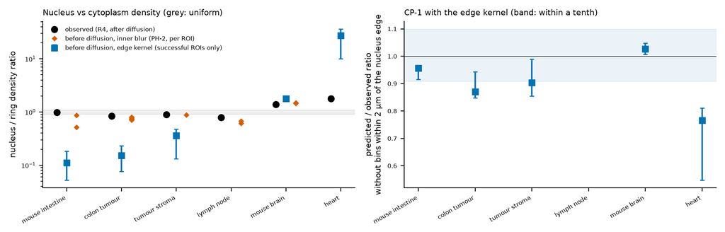

*Cosa guardare*: i rombi arancio (sfocatura interna di PH-2) stanno vicino ai punti neri osservati, un po’ più lontano da 1; i quadrati blu (nucleo dei bordi) sono lontanissimi tranne nel cervello.

# Sfocatura dentro il tessuto (post hoc)

PH-2: sfocatura interna σ_in* per ROI (gaussiana sola, scarto della sezione)

| tag | key | obs_star | obs_far | sigma_in_star | r_at_star | n_sigma | sigma_max_ok | result |
| --- | --- | --- | --- | --- | --- | --- | --- | --- |
| A1_r1 | A1 | 0.973 | 1.005 | NA | NA | 6 | 3.0 | no crossing (closest at 1.5 um, d=-0.113) |
| A1_r2 | A1 | 0.968 | 1.026 | NA | NA | 6 | 3.0 | no crossing (closest at 1 um, d=-0.116) |
| A1_r3 | A1 | 1.001 | 0.960 | 3.368 | 0.520 | 7 | 4.0 | crossing |
| A1_r4 | A1 | 0.990 | 1.040 | NA | NA | 7 | 4.0 | no crossing (closest at 2 um, d=-0.096) |
| A1_r5 | A1 | 0.995 | 0.992 | 0.765 | 0.869 | 7 | 4.0 | crossing |
| A2_r1 | A2 | 0.821 | 0.743 | 0.702 | 0.707 | 6 | 3.0 | crossing |
| A2_r2 | A2 | 0.863 | 0.801 | 0.590 | 0.793 | 6 | 3.0 | crossing |
| A2_r3 | A2 | 0.878 | 0.829 | 0.652 | 0.803 | 7 | 4.0 | crossing |
| A2_r4 | A2 | 0.823 | 0.739 | 0.559 | 0.736 | 6 | 3.0 | crossing |
| A2_r5 | A2 | 0.850 | 0.779 | 0.845 | 0.749 | 6 | 3.0 | crossing |
| A3_r1 | A3 | 0.867 | 0.846 | NA | NA | 7 | 4.0 | no crossing, below grid? no crossing (closest at 0.25 um, d=-0.014) |
| A3_r2 | A3 | 0.953 | 0.977 | NA | NA | 7 | 4.0 | no crossing, below grid? no crossing (closest at 0.25 um, d=-0.032) |
| A3_r3 | A3 | 0.893 | 0.892 | NA | NA | 7 | 4.0 | no crossing, below grid? no crossing (closest at 0.25 um, d=-0.001) |
| A3_r4 | A3 | 0.918 | 0.905 | 0.396 | 0.875 | 7 | 4.0 | crossing |
| A3_r5 | A3 | 0.828 | 0.783 | NA | NA | 6 | 3.0 | no crossing, below grid? no crossing (closest at 0.25 um, d=-0.012) |
| A4_f1 | A4 | 0.761 | 0.732 | NA | NA | 4 | 1.5 | no crossing, below grid? no crossing (closest at 0.25 um, d=-0.051) |
| A4_f2 | A4 | 0.771 | 0.691 | NA | NA | 4 | 1.5 | no crossing, below grid? no crossing (closest at 0.25 um, d=-0.042) |
| A4_p1 | A4 | 0.799 | 0.652 | 0.584 | 0.612 | 4 | 1.5 | crossing |
| A4_p2 | A4 | 0.806 | 0.711 | NA | NA | 4 | 1.5 | no crossing, below grid? no crossing (closest at 0.25 um, d=-0.014) |
| A4_p3 | A4 | 0.804 | 0.680 | 0.251 | 0.680 | 4 | 1.5 | crossing |
| A5_r1 | A5 | 1.384 | 1.529 | 0.694 | 1.471 | 7 | 4.0 | crossing |
| A5_r2 | A5 | 1.373 | 1.538 | 1.994 | 1.489 | 7 | 4.0 | crossing |
| A5_r3 | A5 | 1.414 | 1.579 | 1.614 | 1.490 | 7 | 4.0 | crossing |
| A5_r4 | A5 | 1.345 | 1.514 | 2.536 | 1.463 | 7 | 4.0 | crossing |
| A5_r5 | A5 | 1.398 | 1.544 | 1.085 | 1.486 | 7 | 4.0 | crossing |
| A6_r1 | A6 | 1.617 | 2.636 | NA | NA | 7 | 4.0 | no crossing (closest at 3 um, d=-0.336) |
| A6_r2 | A6 | 2.005 | 4.266 | NA | NA | 6 | 3.0 | no crossing (closest at 3 um, d=-0.847) |
| A6_r3 | A6 | 1.892 | 3.770 | NA | NA | 6 | 3.0 | no crossing, below grid? no crossing (closest at 0.25 um, d=-0.537) |
| A6_r4 | A6 | 1.842 | 3.833 | NA | NA | 7 | 4.0 | no crossing, below grid? no crossing (closest at 0.25 um, d=-0.871) |
| A6_r5 | A6 | 1.564 | 3.034 | NA | NA | 7 | 4.0 | no crossing (closest at 3 um, d=-0.888) |

PH-2s: controprova sintetica

| tag | sigma_true | r_true | obs_star | obs_far | sigma_in_recovered | r_recovered |
| --- | --- | --- | --- | --- | --- | --- |
| A2_r1 | 0.7 | 0.75 | 0.848 | 0.780 | 0.729 | 0.746 |
| A2_r1 | 2.0 | 0.75 | 0.930 | 0.864 | 2.067 | 0.741 |
| A5_r1 | 0.7 | 1.50 | 1.405 | 1.556 | 0.692 | 1.502 |
| A5_r1 | 2.0 | 1.50 | 1.317 | 1.497 | 1.723 | 1.471 |

PH-2 con la coda della sezione

| tag | key | obs_star | obs_far | sigma_in_star | r_at_star | n_sigma | sigma_max_ok | result |
| --- | --- | --- | --- | --- | --- | --- | --- | --- |
| A2_r1 | A2 | 0.821 | 0.743 | 0.692 | 0.693 | 5 | 3.0 | crossing |
| A2_r2 | A2 | 0.863 | 0.801 | 0.584 | 0.783 | 5 | 3.0 | crossing |
| A2_r3 | A2 | 0.878 | 0.829 | 0.645 | 0.793 | 6 | 4.0 | crossing |
| A2_r4 | A2 | 0.823 | 0.739 | 0.561 | 0.722 | 5 | 3.0 | crossing |
| A2_r5 | A2 | 0.850 | 0.779 | 0.839 | 0.736 | 5 | 3.0 | crossing |
| A3_r1 | A3 | 0.867 | 0.846 | NA | NA | 6 | 4.0 | no crossing, below grid? no crossing (closest at 0.5 um, d=-0.023) |
| A3_r2 | A3 | 0.953 | 0.977 | NA | NA | 6 | 4.0 | no crossing, below grid? no crossing (closest at 0.5 um, d=-0.034) |
| A3_r3 | A3 | 0.893 | 0.892 | NA | NA | 6 | 4.0 | no crossing, below grid? no crossing (closest at 0.5 um, d=-0.009) |
| A3_r4 | A3 | 0.918 | 0.905 | NA | NA | 6 | 4.0 | no crossing, below grid? no crossing (closest at 0.5 um, d=-0.003) |
| A3_r5 | A3 | 0.828 | 0.783 | NA | NA | 5 | 3.0 | no crossing, below grid? no crossing (closest at 0.5 um, d=-0.025) |
| A4_f1 | A4 | 0.761 | 0.732 | NA | NA | 3 | 1.5 | no crossing, below grid? no crossing (closest at 0.5 um, d=-0.087) |
| A4_f2 | A4 | 0.771 | 0.691 | NA | NA | 3 | 1.5 | no crossing, below grid? no crossing (closest at 0.5 um, d=-0.075) |
| A4_p1 | A4 | 0.799 | 0.652 | 0.565 | 0.576 | 3 | 1.5 | crossing |
| A4_p2 | A4 | 0.806 | 0.711 | NA | NA | 3 | 1.5 | no crossing, below grid? no crossing (closest at 0.5 um, d=-0.047) |
| A4_p3 | A4 | 0.804 | 0.680 | NA | NA | 3 | 1.5 | no crossing, below grid? no crossing (closest at 0.5 um, d=-0.033) |
| A5_r1 | A5 | 1.384 | 1.529 | 0.688 | 1.543 | 6 | 4.0 | crossing |
| A5_r2 | A5 | 1.373 | 1.538 | 1.979 | 1.559 | 6 | 4.0 | crossing |
| A5_r3 | A5 | 1.414 | 1.579 | 1.596 | 1.559 | 6 | 4.0 | crossing |
| A5_r4 | A5 | 1.345 | 1.514 | 2.562 | 1.539 | 6 | 4.0 | crossing |
| A5_r5 | A5 | 1.398 | 1.544 | 1.061 | 1.554 | 6 | 4.0 | crossing |

PH-2 con scarto 0 (intestino, cuore)

| tag | key | obs_star | obs_far | sigma_in_star | r_at_star | n_sigma | sigma_max_ok | result |
| --- | --- | --- | --- | --- | --- | --- | --- | --- |
| A1_r1 | A1 | 0.973 | 1.005 | NA | NA | 6 | 4 | no crossing, below grid? no crossing (closest at 0.5 um, d=-0.047) |
| A1_r2 | A1 | 0.968 | 1.026 | NA | NA | 6 | 4 | no crossing, below grid? no crossing (closest at 0.5 um, d=-0.040) |
| A1_r3 | A1 | 1.001 | 0.960 | NA | NA | 6 | 4 | no crossing (closest at 4 um, d=+0.009) |
| A1_r4 | A1 | 0.990 | 1.040 | NA | NA | 6 | 4 | no crossing, below grid? no crossing (closest at 0.5 um, d=-0.046) |
| A1_r5 | A1 | 0.995 | 0.992 | 3.503 | 0.684 | 6 | 4 | crossing |
| A6_r1 | A6 | 1.617 | 2.636 | NA | NA | 6 | 4 | no crossing (closest at 3 um, d=-0.324) |
| A6_r2 | A6 | 2.005 | 4.266 | NA | NA | 6 | 4 | no crossing (closest at 3 um, d=-0.777) |
| A6_r3 | A6 | 1.892 | 3.770 | NA | NA | 6 | 4 | no crossing (closest at 3 um, d=-0.641) |
| A6_r4 | A6 | 1.842 | 3.833 | NA | NA | 6 | 4 | no crossing (closest at 3 um, d=-0.975) |
| A6_r5 | A6 | 1.564 | 3.034 | NA | NA | 6 | 4 | no crossing (closest at 3 um, d=-0.864) |

PH-5: bordi con la parte gaussiana fissata a 0.7 µm

| key | n_tiles | sigma_fixed | median_dnll | median_dnll_per_1000_bins | frac_dnll_gt_2 | frac_dnll_lt_0 | median_w_narrow | median_ell_narrow | median_sigma_free | median_w_free |
| --- | --- | --- | --- | --- | --- | --- | --- | --- | --- | --- |
| A1 | 130 | 0.7 | 419.278 | 32.149 | 0.985 | 0.000 | 0.860 | 5.000 | 5.160 | 0.099 |
| A23 | 59 | 0.7 | 1294.576 | 118.158 | 1.000 | 0.000 | 0.459 | 5.000 | 3.461 | 0.058 |
| A4 | 73 | 0.7 | 1.701 | 0.095 | 0.452 | 0.014 | 0.557 | 8.670 | 3.372 | 0.121 |
| A5 | 47 | 0.7 | 94.255 | 9.757 | 1.000 | 0.000 | 0.547 | 5.000 | 3.084 | 0.151 |
| A6 | 5 | 0.7 | 43.634 | 4.399 | 1.000 | 0.000 | 0.701 | 5.547 | 3.236 | 0.382 |

PH-4 (regola R-4): rapporto di R4 con le maschere spostate dello scarto della sezione

| archetype | sign | mask | estimate | lo | hi | class_vs_0.909_1.1 | frac_nuc_bins_same_label_mean | spearman_nuc_umi_mean | R4_PH1_estimate | R4_PH1_lo | R4_PH1_hi |
| --- | --- | --- | --- | --- | --- | --- | --- | --- | --- | --- | --- |
| A1 | -1 | shifted by -delta (control) | 1.0502 | 1.0386 | 1.0630 | confermata | 0.3359 | 0.8198 | 0.9856 | 0.9747 | 0.9966 |
| A1 | 0 | R4 (no shift) | 0.9856 | 0.9747 | 0.9966 | confermata | 1.0000 | 1.0000 | 0.9856 | 0.9747 | 0.9966 |
| A1 | 1 | shifted by section delta (aligned) | 0.9376 | 0.9285 | 0.9455 | confermata | 0.3370 | 0.8272 | 0.9856 | 0.9747 | 0.9966 |
| A2 | -1 | shifted by -delta (control) | 0.8427 | 0.8241 | 0.8608 | smentita | 0.9471 | 0.9786 | 0.8470 | 0.8277 | 0.8662 |
| A2 | 0 | R4 (no shift) | 0.8470 | 0.8277 | 0.8662 | smentita | 1.0000 | 1.0000 | 0.8470 | 0.8277 | 0.8662 |
| A2 | 1 | shifted by section delta (aligned) | 0.8544 | 0.8359 | 0.8728 | smentita | 0.9464 | 0.9784 | 0.8470 | 0.8277 | 0.8662 |
| A3 | -1 | shifted by -delta (control) | 0.8917 | 0.8546 | 0.9277 | indeterminata | 0.9481 | 0.9834 | 0.8918 | 0.8538 | 0.9279 |
| A3 | 0 | R4 (no shift) | 0.8918 | 0.8538 | 0.9279 | indeterminata | 1.0000 | 1.0000 | 0.8918 | 0.8538 | 0.9279 |
| A3 | 1 | shifted by section delta (aligned) | 0.8984 | 0.8613 | 0.9338 | indeterminata | 0.9479 | 0.9828 | 0.8918 | 0.8538 | 0.9279 |
| A4 | -1 | shifted by -delta (control) | 0.8055 | 0.7848 | 0.8261 | smentita | 0.8691 | 0.8477 | 0.7880 | 0.7717 | 0.8034 |
| A4 | 0 | R4 (no shift) | 0.7880 | 0.7717 | 0.8034 | smentita | 1.0000 | 1.0000 | 0.7880 | 0.7717 | 0.8034 |
| A4 | 1 | shifted by section delta (aligned) | 0.8034 | 0.7879 | 0.8181 | smentita | 0.8714 | 0.8465 | 0.7880 | 0.7717 | 0.8034 |
| A5 | -1 | shifted by -delta (control) | 1.3758 | 1.3558 | 1.3921 | smentita | 0.9357 | 0.9945 | 1.3827 | 1.3616 | 1.4015 |
| A5 | 0 | R4 (no shift) | 1.3827 | 1.3616 | 1.4015 | smentita | 1.0000 | 1.0000 | 1.3827 | 1.3616 | 1.4015 |
| A5 | 1 | shifted by section delta (aligned) | 1.3905 | 1.3728 | 1.4083 | smentita | 0.9359 | 0.9946 | 1.3827 | 1.3616 | 1.4015 |
| A6 | -1 | shifted by -delta (control) | 1.5961 | 1.4544 | 1.7377 | smentita | 0.4927 | 0.8707 | 1.7840 | 1.6401 | 1.9274 |
| A6 | 0 | R4 (no shift) | 1.7840 | 1.6401 | 1.9274 | smentita | 1.0000 | 1.0000 | 1.7840 | 1.6401 | 1.9274 |
| A6 | 1 | shifted by section delta (aligned) | 1.5011 | 1.4138 | 1.5912 | smentita | 0.5385 | 0.8593 | 1.7840 | 1.6401 | 1.9274 |

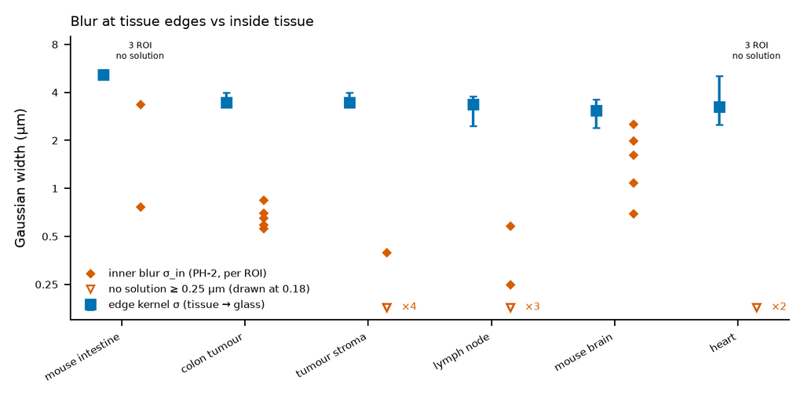

*Cosa guardare*: i quadrati blu (bordi) stanno a 3-5 µm in tutte le sezioni; i rombi arancio (dentro il tessuto) stanno sotto 1 µm nel tumore, nello stroma e nel linfonodo, fra 0.7 e 2.5 µm nel cervello.

# Dopo il risultato

Numeri del calcolo finale (`run3`, identico a `run4`), con l’ottimizzatore corretto dopo la revisione numerica. Il primo calcolo (`run1`, prima della revisione) è in `results/R5/run1_before_review/`; gli esiti delle previsioni non cambiano, i valori sì (sotto, «Revisione avversariale»).

## Esiti come scritti

- G-1 FALLITO come scritto: `tools/R5_test.py` 98/105 asserzioni nel calcolo finale (ottimizzatore corretto, semi deterministici, T12 nuovo). Falliscono 7 asserzioni, tutte di identificabilità: w sulla geometria «a macchia» (+0.069 contro 0.01) e lo scarto sul bordo curvo con σ = 3 e 5 µm (scostamenti della mediana 0.28-0.50 µm contro 0.25, con dispersione fra tessere 0.5-0.8 µm). Tutte le asserzioni su σ passano. Prima della revisione: 98/104 (semi non riproducibili, DV-16). Mutanti sul codice finale (regola relativa alla versione non mutata): M1-M5 e X1 rilevati, M0 (nullo) non rilevato (`/mnt/micron/geo_spatialtrans/R5/G1_mutants_final.log`). Due errori standard tipici della mediana di sezione su sintetico: σ 0.05-0.08 µm (cuore 0.26), w 0.002-0.003 (cuore 0.009), scarto 0.13-0.22 µm (cuore 0.68).
- G-2 PASS: 159 file letti con md5 identico prima e dopo; `results/R2`, `R4`, `R6` invariati rispetto al commit (`tools/R5_G2.sh`, `results/R5/R5_G2.txt`).
- G-3 FALLITO come scritto: (a) con tutte le feature della matrice grezza fallisce in tutte le sezioni (la grezza ha più geni della filtrata); con i geni della filtrata (DV-1) passa 5/5; (b) PASS: nessun bin a 8 µm diverso dalla somma dei suoi 16 bin a 2 µm; (c) PASS: totali per cellula e strati identici a R4 in 30/30 ROI, e statistica osservata identica a R4 PH-1; (d) PASS: stessi file di posizione di R4 (`results/R5/R5_G3.txt`).
- G-4 PASS: 24/24 file identici fra due esecuzioni complete (`run3`, `run4`): 22 tabelle di calcolo e post hoc, `kernels.json`, `params.json` (`tools/R5_repro2.sh`, `results/R5/R5_G4.txt`).
- G-5: due revisori (sotto).
- P-1 (σ della parte gaussiana di K2, atteso in [1, 4] µm): confermata nel tumore del colon 3.46 [3.35, 3.98], nel linfonodo 3.37 [2.46, 3.77] e nel cervello 3.08 [2.41, 3.62]; smentita nell’intestino 5.16 [4.88, 5.53]; indeterminata nel cuore 3.24 [2.51, 5.07] (5 tessere).
- P-2 (coda, w sopra 0.01): confermata in tutte le sezioni: intestino 0.099 [0.088, 0.110], tumore del colon 0.058 [0.049, 0.069], linfonodo 0.121 [0.084, 0.209], cervello 0.151 [0.117, 0.213], cuore 0.38 [0.15, 0.62]. Lunghezza della coda ℓ: 26.8, 15.0, 38.1, 21.8, 11.7 µm. Regola R-1: nucleo con coda esponenziale in tutte le sezioni.
- P-3 (σ_riga/σ_colonna in [0.8, 1.25]): confermata in intestino 0.983 [0.899, 1.043], tumore del colon 0.990 [0.931, 1.057], linfonodo 1.000 [0.894, 1.000], cervello 0.988 [0.862, 1.156]; indeterminata nel cuore 0.75 [0.21, 1.89]. Regola R-3: isotropo.
- P-4 (|δ| entro 1 µm): smentita nell’intestino 2.36 [2.04, 2.64] µm (quasi tutto lungo le colonne: −2.35 µm); confermata nel tumore del colon 0.17 [0.08, 0.65]; indeterminata nel linfonodo 0.57 [0.34, 1.39] e nel cuore 2.26 [0.70, 6.15]; cervello, senza attesa, 0.49 [0.21, 2.02]. Regola R-4: sensibilità di R4 con le maschere spostate nell’intestino (PH-4).
- Regola R-2: rapporto fra il σ più grande e il più piccolo 1.67 [1.54, 2.24], tutto sopra 1.25 → σ per tessuto.
- Riferimenti descrittivi D-2 (spostamento medio; frazione oltre 8 µm): intestino 11.1 µm, 0.37; tumore del colon 5.8 µm, 0.12; linfonodo 12.9 µm, 0.17; cervello 9.9 µm, 0.17; cuore 11.4 µm, 0.35. D-4 (variabilità dello scarto fra tessere, scarto interquartile per riga e colonna): da 1.5 a 4.8 µm.
- P-5 (rapporto prima della diffusione con il nucleo dei bordi): come scritta (media di tutte le ROI) non calcolabile in intestino, tumore del colon, stroma, linfonodo e cuore (almeno una ROI o parte delle repliche non si invertono); confermata nel cervello 1.77 [1.62, 1.95]. Sensibilità sulle sole ROI riuscite: intestino 0.11 (smentita, attesa uniforme), tumore del colon 0.15, stroma 0.36, cuore 27 (valori fisicamente implausibili), linfonodo non invertibile in 5/5.
- CP-1 (previsto/osservato senza i bin entro 2 µm dal bordo del nucleo, in [0.909, 1.1]): superata solo nel cervello 1.026 [1.007, 1.048]; come scritta non calcolabile negli altri tessuti; sulle ROI riuscite tumore del colon 0.871 [0.848, 0.944] indeterminata, cuore 0.77 [0.55, 0.81] smentita. Come la pre-registrazione prevedeva in caso di fallimento: il nucleo dei bordi esterni non descrive la sfumatura dentro il tessuto, e r_vero di P-5 non è affidabile fuori dal cervello (PH-2, PH-3).
- CP-2 (lumi, osservato/previsto in [0.8, 1.25] per fascia 2-4, 4-8, 8-16, 16-32 µm): intestino 1.06, 1.11 confermate, 1.27 e 1.29 indeterminate (138 lumi); tumore del colon 0.79 indeterminata, 1.11 confermata, 1.52 smentita, 1.46 indeterminata (50 lumi: più RNA del previsto lontano dal bordo); linfonodo 1.08 confermata, 1.20 e 1.22 indeterminate, 1.13 confermata (446 lumi, quasi tutti adipociti); cervello 0.85, 0.81 indeterminate, 0.62 e 0.51 smentite (2 soli lumi); cuore 1.08 confermata, 0.87, 0.71, 0.65 indeterminate (53 lumi). Entro 8 µm dal bordo il nucleo dei bordi prevede i lumi entro un quarto in 9 fasce su 10.
- CP-3 FALLITA come scritta in 5/5: con la maschera spostata di (+2, −2) µm lo scarto stimato cambia del 60-80 % dello spostamento (intestino −1.35/+1.40 µm, linfonodo −1.20/+1.26) invece del 100 %. L’attesa era sbagliata (Errori di pre-registrazione; PH-1). σ e w restano entro le tolleranze di G-1.

## Scelte decise dai dati e deviazioni dichiarate

Numerate DV-n per non confonderle con i riferimenti descrittivi D-1…D-4 (revisione del codice, F12).

- DV-1 (G-3 a). La matrice grezza a 2 µm ha più feature della filtrata (intestino 32 285 contro 19 059; tumore del colon e linfonodo 39 125 contro 18 132; cervello 33 715 contro 19 070; cuore 37 082 contro 18 085). I conteggi per bin di tutto lo step sono la somma sui geni della filtrata.
- DV-2 (maschera del tessuto). La maschera H&E di R2 perde il tessuto pallido (neuropilo, miocardio chiaro; limite già noto da S1.3c): sui profili di 5 tessere, guardati prima di ogni adattamento, i bin «di vetro» appena fuori dalla maschera avevano livelli da tessuto. Maschera usata: R2 unita a densità ottica totale > 0.15 (vetro 0.075-0.125), bolle escluse (`tools/R5_tiles.py`, `results/R5/R5_D4_od.txt`, figure `R5_E2_*`).
- DV-3 (registrazione). Trasformazione griglia → immagine affine per regione (residuo massimo ≤ 0.94 pixel).
- DV-4 (stimatore, G-1). Una variante (densità dai soli bin interni, fondo fissato dal vetro lontano) provata su sintetico e scartata (82/104 contro 95/104): si usa lo stimatore pre-registrato; la variante resta come sensibilità S-0.
- DV-5 (inversione del rapporto). Dopo il primo fallimento di T7 l’inversione ha un passo autoconsistente delle densità per cellula (2 passi).
- DV-6 (incertezza del rapporto). Bootstrap a due sorgenti approssimato con 20 nuclei estratti dal bootstrap delle tessere (F10).
- DV-7 (G-1, criterio). Recupero giudicato sulla mediana di 30 tessere sintetiche per configurazione; aggiunta una geometria «a macchia» per lo scarto in entrambe le direzioni.
- DV-8 (S-0, S-2). S-0 ricalcolata per un errore di sostituzione dei parametri nella prima esecuzione; S-2 aveva un errore che cambiava insieme parità e densità (F13): corretto nel codice (`tools/R5_fit.py`) e rifatto nel calcolo finale.
- DV-9 (CP-2). Lumi cercati nelle tessere con frazione `in_tissue` di Space Ranger ≥ 0.5 (F18).
- DV-10 (S-4). «Tessere di 200 µm» realizzata come i 200 µm centrali della tessera (F20).
- DV-11 (P-4). Si giudica la definizione registrata (modulo del vettore delle mediane); la mediana dei moduli per tessera è una sensibilità (F06): tumore del colon 1.39 µm invece di 0.17.
- DV-12 (sensibilità aggiunte dopo la revisione del codice): tessere a convergenza e lontane dai limiti (F16), tessere senza tessuto fuori dall’area di cattura (F14), rapporto di K3 con il solo adattamento che si è mosso dal punto di partenza (F21).
- DV-13 (P-5, CP-1; revisione numerica F-8). La prima analisi dava «non valutabile» con almeno 3 ROI non invertibili e mediava le sole ROI riuscite: regole non pre-registrate. Ora l’esito come scritto (media di tutte le ROI; «non calcolabile come scritto» se una ROI o una replica non si inverte) e la media delle ROI riuscite come sensibilità.
- DV-14 (limiti dei parametri; F-2, F-7). La prima esecuzione limitava w ≤ 0.5 (non pre-registrato, attivo in diverse tessere). Ora w ∈ [0, 1] come scritto; w ≤ 0.5 è la sensibilità S-W (cambia solo il linfonodo: σ 3.58 invece di 3.37, 14 tessere con w > 0.5). Restano i limiti tecnici σ ∈ [0.2, 10] µm (17 tessere del linfonodo al limite inferiore: distribuzione a due gruppi), scarto entro ±6 µm (13 tessere al limite, 10 nel cervello), ℓ ≥ 5 µm.
- DV-15 (ottimizzatore; F-1, F-3). Correzione di un difetto, non dello stimatore: griglia di partenza (160 punti, poi i 3 migliori più i 2 avvii fissi), rifinitura finale (Nelder-Mead e L-BFGS-B), profilazione di a con b al limite. Il segnale di convergenza dell’ottimizzatore resta falso in molte tessere (fine per perdita di precisione nella ricerca lineare; per esempio 54/130 nell’intestino); l’ottimalità è verificata dal controllo di accettazione sulle 37 tessere del revisore (37/37) e la sensibilità sulle sole tessere «a convergenza e lontane dai limiti» dà σ simili (5.33, 3.51, 3.95, 3.34, 3.31 µm).
- DV-16 (G-1, semi). I semi delle tessere sintetiche usavano `hash()` di Python, diverso a ogni processo: le tessere della prima G-1 non sono riproducibili. Ora semi deterministici e test T12; G-1 rifatto con l’ottimizzatore nuovo. Il confronto con l’ottimizzatore vecchio sulle stesse tessere sintetiche è stato preparato ma non eseguito (4-6 ore di calcolo; sui dati veri l’effetto della correzione è già misurato dal controllo di accettazione, 37/37); BL-202.
- DV-17 (risorse). Processi limitati dalla temperatura della CPU (protezione `tools/R5_thermal_guard.sh`, seconda versione dal 2026-11-02 21:30 estesa al post hoc e ai test); sospensioni registrate in `/mnt/micron/geo_spatialtrans/R5/guard.log`. Le sospensioni non cambiano i risultati (G-4).

## Analisi post hoc (dichiarate dopo i risultati)

- PH-1 (CP-3, `tools/R5_ph_cp3_synth.py`): su tessere sintetiche, spostare la maschera di (+2, −2) µm sposta lo scarto stimato dell’87-93 % con σ = 2 µm e del 76-86 % con σ = 5 µm; uno scarto vero dei conteggi si ritrova intero (−2.31 e −2.55 contro −2.5). L’attesa corretta di CP-3 sarebbe stata «circa l’80-90 %»; i dati veri danno 60-80 %.
- PH-2 (CP-1, `tools/R5_ph2_inner.py`): larghezza della sfocatura **dentro** il tessuto. Per ogni ROI e per σ_in in {0.25, 0.5, 1, 1.5, 2, 3, 4} µm (gaussiana sola, scarto della sezione) si inverte r sulla statistica di R4 PH-1 e si prevede la stessa statistica senza i bin entro 2 µm dal bordo del nucleo; σ_in* è il valore per cui prevista e osservata coincidono.
  - tumore del colon: 0.56-0.84 µm in 5/5 ROI, con r da 0.71 a 0.80 (osservato 0.82-0.88);
  - cervello: 0.69-2.54 µm in 5/5 (curva piatta, poco identificata), r 1.46-1.49 (osservato 1.35-1.41);
  - stroma: 0.40 µm in 1/5; nelle altre 4 nessuna soluzione da 0.25 µm in su (differenza a 0.25 µm da −0.001 a −0.032: o σ_in < 0.25 µm o il modello manca di poco);
  - linfonodo: 0.58 e 0.25 µm in 2/5; nelle altre 3 nessuna soluzione da 0.25 µm in su (differenza −0.014…−0.051);
  - intestino: 0.77 e 3.37 µm in 2/5; nelle altre 3 nessun σ riproduce entrambe le statistiche (quella lontana dal bordo sta sopra 1, quella intera sotto);
  - cuore: nessuna soluzione (la statistica lontana dal bordo vale 2.6-4.3 contro 1.6-2.0 dell’intera; il modello resta sotto di 0.3-0.9).
- PH-2s (controprova sintetica, `tools/R5_ph2_synth.py`): conteggi generati sulla geometria vera di una ROI del tumore (r = 0.75) e di una del cervello (r = 1.5) con σ_vero = 0.7 e 2 µm: ritrovati 0.73 e 2.07 µm (tumore), 0.69 e 1.72 µm (cervello), r entro il 2 %.
- PH-2 con la coda della sezione (w, ℓ di K2) dentro il tessuto: σ_in* quasi uguale (tumore 0.56-0.84 µm; cervello 0.69-2.56 µm), r un po’ più lontano da 1 (tumore 0.69-0.79; cervello 1.54-1.56): la coda dentro il tessuto non si può né escludere né misurare con il contrasto dei nuclei.
- PH-2 con scarto 0 (intestino, cuore): nessun miglioramento (intestino 1/5, cuore 0/5): i fallimenti non vengono dallo scarto.
- PH-3 (F07, C12; `tools/R5_ph3_reach.py`): con il nucleo dei bordi, per r da 0.05 a 50, la statistica nel linfonodo non scende sotto 0.945-0.964 contro 0.761-0.806 osservati (5/5 fuori portata); nell’intestino 2/5 fuori portata. Nel cuore con il nucleo corretto (w 0.38) l’osservato è raggiungibile in 5/5, ma solo con r ≈ 27.
- PH-4 (regola R-4, `tools/R5_ph4_r4shift.py`): la statistica di R4 PH-1 con le maschere dei nuclei spostate dello scarto della sezione; senza spostamento riproduce R4 esattamente. Intestino: 0.986 [0.975, 0.997] → 0.938 [0.928, 0.946]; il contrasto aumenta in 5/5 ROI, e con lo spostamento opposto sale a 1.050: lo scarto misurato ai bordi vale anche dentro il tessuto. La classe di R4 non cambia (uniforme); ma solo il 34 % dei bin del nucleo resta allo stesso nucleo: le impronte di R6 nell’intestino vanno lette con la riserva. Cuore: 1.784 → 1.501, il contrasto diminuisce (lo scarto dei 5 bordi del cuore non vale dentro). Nelle altre sezioni cambi ≤ 0.02.
- PH-5 (`tools/R5_ph5_narrowcore.py`): i bordi con la parte gaussiana fissata a 0.7 µm (coda e scarto liberi) peggiorano la verosimiglianza in mediana di 419 unità per tessera nell’intestino, 1 295 nel tumore del colon, 94 nel cervello, 44 nel cuore (oltre 2 unità nel 98-100 % delle tessere); nel linfonodo solo 1.7 (45 %), coerente con le sue tessere a σ piccolo. Il bordo verso il vetro è davvero sfumato su 3-5 µm: due scale diverse, ai bordi e dentro.

## Revisione avversariale

Due revisori indipendenti, in sola lettura sul repository e sul primo calcolo (`run1`, commit `463ba9d` più le modifiche allora in corso).

- **Revisore del codice** (rapporto `/mnt/micron/geo_spatialtrans/R5/review_code/R5_review_code.md`): convenzioni corrette (segno dello scarto, campionamento, mappatura griglia → immagine, normalizzazione del nucleo); 21 rilievi. Corretti: F02 (regola dei mutanti relativa alla versione non mutata), F03 e F04 (test nuovi T10, convenzioni assolute, e T11, mappatura), F07 (inversioni impossibili mostrate come «non invertibile»), F09 (P-5 ignorava «più lontano da 1»), F13 (errore in S-2, che cambiava insieme parità e densità; ricalcolata), F14, F16, F21 (sensibilità aggiunte). Dichiarati come deviazioni: F05 (CP-3), F06 (definizione di P-4), F10, F11, F12, F18, F20. Limiti dichiarati dal revisore: rapporto ancora parziale (325 su 660) al momento della revisione, G-4 non verificato, mutanti sui soli test economici.
- **Revisore numerico** (rapporto `R5_review_numeric.md`): ricalcolo da zero con codice proprio. A identità: UMI per bin sull’intera griglia di tumore del colon e cervello (0 bin diversi su 11 222 500), selezione delle tessere (0 discrepanze su 5 × 484 candidati), mediane e intervalli di P-1…P-4, CP-3, R-2 (≤ 4.4e-16), CP-2 (≤ 1.1e-16), statistica osservata del rapporto nelle 30 ROI (= R4 PH-1, 2.2e-16), modello in avanti (contro integrazione diretta 4.5e-4), convenzione di segno, inversione nel cervello (r 1.973-1.977 contro 1.980), fallimento reale nel linfonodo (statistica raggiungibile 0.956-1.071 contro 0.761 osservato). Rilievi principali: F-1 l’ottimizzatore non raggiungeva l’ottimo in 13 di 37 tessere rifatte da zero (in 5 di oltre 1 unità di verosimiglianza: −237, −67, −31, −24, −1.1), soprattutto con w al limite 0.5 e ℓ vicino a 5 µm; F-2 il limite w ≤ 0.5 non era pre-registrato; F-3 profilazione di (a, b) con b al limite; F-4 avvolgimento della FFT con ℓ > 100 µm (effetto sui parametri entro il 3 %); F-5 CP-3 non può passare nemmeno con il modello giusto (1.55-1.86 µm su 2); F-6 G-1 98/104 non dichiarato come fallito; F-8 regole di P-5 non pre-registrate; F-9 il nucleo dei bordi è troppo largo per il contrasto interno (scientifico, non di implementazione). Limiti dichiarati dal revisore: avvii troncati dell’adattamento da zero, CP-3 rifatto su 15 tessere, impatto sulle mediane provvisorio (8 tessere ricalcolate).
- **Correzioni dopo la revisione numerica**: ottimizzatore con griglia di partenza (160 punti per tessera, poi i 3 migliori più i 2 avvii fissi) e rifinitura finale (Nelder-Mead e L-BFGS-B dal punto migliore); w stimato direttamente in [0, 1] come scritto (F-2, DV-14), w ≤ 0.5 come sensibilità S-W; profilazione di a con b al limite (F-3); verdetti di P-5 e CP-1 come scritti (F-8, DV-13). Controllo di accettazione (`tools/R5_review_refit_check.py`, `results/R5/review/R5_review_refit_check_w05.csv`): sulle 37 tessere del revisore la nuova soluzione non è mai peggiore né della salvata né di quella del revisore (37/37; prima della rifinitura 22/37). Poi G-1 rifatto e due esecuzioni complete nuove (`run3`, `run4`) con il post hoc; `run1` resta come calcolo prima della revisione (`results/R5/run1_before_review/`). Effetto sulle stime: in 51 delle 130 tessere dell’intestino la verosimiglianza migliora (in 24 di oltre 1 unità), in nessuna peggiora; le tessere bloccate a w = 0.5 erano 14. Mediane: intestino σ 4.88 → 5.16 µm, w 0.108 → 0.099; tumore del colon 3.46 → 3.46; linfonodo 3.58 → 3.37 (con w ≤ 0.5: 3.58); cervello 3.03 → 3.08; cuore 3.30 → 3.24 e w 0.50 → 0.38 (il valore stimato dal revisore). L’impatto nell’intestino è più grande della stima provvisoria del revisore, fatta su 8 tessere. Nessun esito di previsione cambia.

## Errori di pre-registrazione

- G-3 (a) come scritto non poteva passare: la matrice grezza contiene geni che la filtrata non ha (DV-1). L’errore è nel controllo, non nei dati.
- La maschera del tessuto pre-registrata (R2) aveva un limite già documentato in S1.3c (tessuto pallido), che avrei dovuto prevedere (DV-2).
- CP-3: l’attesa «lo scarto cambia di (−2, +2) µm» era sbagliata. Spostare la maschera non equivale a spostare i conteggi, perché anche la densità del tessuto e la parità si ricalcolano con la maschera spostata (revisore numerico, F-5); l’attesa corretta sarebbe stata circa l’80-90 % (PH-1).
- G-1: le asserzioni fallite sono di identificabilità, non di codice: la batteria chiedeva di recuperare lo scarto lungo direzioni in cui il bordo non porta informazione e σ = 5 µm con una tolleranza di 0.40 µm su geometrie piccole. Nel calcolo finale (98/105) falliscono w sulla geometria «a macchia» e lo scarto sul bordo curvo con σ = 3 e 5 µm; tutte le asserzioni su σ passano.
- La tolleranza e i limiti dei parametri dell’ottimizzatore (w ≤ 0.5) non erano nella pre-registrazione: una scelta di codice ha cambiato per due giorni lo stimatore senza che nessuno la vedesse (F-2).

# Cosa è girato

Server lesexp (stessa macchina dei due nomi), `.venv` del progetto. Primo calcolo `/mnt/micron/geo_spatialtrans/R5/run1` (e `run2`), prima della revisione numerica; calcolo finale `run3` e `run4` (G-4) con l’ottimizzatore corretto, ciascuno con `tools/R5_run.sh` e `tools/R5_posthoc.sh`. Seme 20261031, B = 2000. Processi limitati dalla temperatura della CPU (protezione `tools/R5_thermal_guard.sh`).